# STAT 547 Class Meeting 01: Writing your own Functions

```r
library(gapminder)
library(tidyverse)
library(testthat)
```

This worksheet is a condensed version of Jenny’s stat545.com functions [part1](http://stat545.com/block011_write-your-own-function-01.html), [part2](http://stat545.com/block011_write-your-own-function-02.html), and [part3](http://stat545.com/block011_write-your-own-function-03.html).

## Syntax Demo

Let’s demo the syntax of function-making.

> function(arguments)

```r
# square <- function(x) X^2
# square <- function(x) {
#  y <- x^2
#  y
#  }
# square <- function(x) {
#  y <- x^2
#  return(y) #r will stop what it's doing and return y, if you want to stop the function early (it won't return anything after return())
#  }
# square(10) returns 100
```

## Motivating example: max minus min.

Find the max minus min of the gapminder life expectancy:

```r
?min
?max
max(gapminder$lifeExp) - min(gapminder$lifeExp)
```

```
[1] 59.004
```

Exercise: turn this into a function! i.e., write a function that returns the max minus min of a vector. Try it out on the gapminder variables.

```r
max_minus_min <- function(x) {
  (max(x) - min(x))
}
max_minus_min(gapminder$lifeExp)
```

```
[1] 59.004
```

We’ll be building on this. Development philosophy [widely attributed to the Spotify development team](http://blog.fastmonkeys.com/?utm_content=bufferc2d6e&utm_medium=social&utm_source=twitter.com&utm_campaign=buffer):

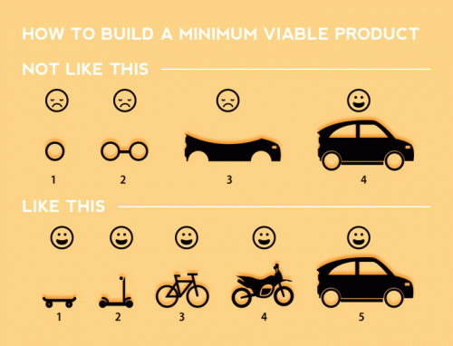

## Testing

Check your function using your own eyeballs:

- Apply to the vector 1:10. Do you get the intended result?
- Apply to a random uniform vector. Do you get meaningful results?

```r
max_minus_min(1:10)
```

```
[1] 9
```

```r
max_minus_min(runif(100))
```

```
[1] 0.9882299
```

Let’s formalize this testing with the `testthat` package. `expect_*()` functions:

> expect_something functions in testthat package. Errors if test doesn’t pass, returns nothing if it does pass. expect_equal tests if two arguments are equal. If test passes, doesn’t return anything. expect_idential is stricter all arguments separated by a comma expect_true, expect_less…than?

```r
expect_equal(0.1 + 0.2, 0.3)
expect_identical(0.1 + 0.2, 0.3)
```

```
Error: 0.1 + 0.2 not identical to 0.3.
Objects equal but not identical
```

Add another check to the following unit test, based on the uniform random numbers:

> test_that(“name of test that’s readable to you”, {the test itself}) test_that is more self-documenting

```r
test_that("Simple cases work", {
    expect_equal(max_minus_min(1:10), 9)
    expect_lt(max_minus_min(runif(100)), 1)
})
```

## Try and break your function

Because you will eventually forget the function specifics.

```r
max_minus_min(numeric(0))
```

```
no non-missing arguments to max; returning -Infno non-missing arguments to min; returning Inf
```

```
[1] -Inf
```

```r
max_minus_min(gapminder)
```

```
Error in FUN(X[[i]], ...) :
  only defined on a data frame with all numeric variables
```

These don’t break!

```r
max_minus_min(gapminder[c('lifeExp', 'gdpPercap', 'pop')])
```

```
[1] 1318683072
```

```r
max_minus_min(c(TRUE, TRUE, FALSE, TRUE, TRUE))
```

```
[1] 1
```

We want:

1. Prevent the latter cases from happening, and
2. Make a more informative error message in the former.

Check out `stopifnot` and `stop`:

```r
stopifnot(FALSE)
```

```
Error: FALSE is not TRUE
```

Your turn: Use two methods:

1. Using `stopifnot`, modify the max-min function to throw an error if an input is not numeric (the `is.numeric` function is useful).

```r
mmm1 <- function(x) {
    stopifnot(!is.numeric(x))
    max(x) - min(x)
}
mmm1("hello")
```

```
Error in max(x) - min(x) : non-numeric argument to binary operator
```

2. Using `stop` and an `if` statement, Modify the max-min function to:
   - throw an error if an input is not numeric. In the error message, indicate what’s expected as an argument, and what was recieved.
   - return `NULL` if the input is length-0, with a warning using the `warning` function.

```r
mmm2 <- function(x) {
    if (!is.numeric(x)) {
        stop(paste("Expecting x to be numberic. You gave me"),
             typeof(x)))
```

```
Error: unexpected ')' in:
"        stop(paste("Expecting x to be numberic. You gave me"),
             typeof(x)))"
```

Try breaking the function now:

```r
mmm1((numeric(0)))
mmm1(gapminder)
mmm1(gapminder$country)
mmm1(gapminder[c('lifeExp', 'gdpPercap', 'pop')])
mmm1(c(TRUE, TRUE, FALSE, TRUE, TRUE))

mm2((numeric(0)))
mmm2(gapminder)
mmm2(gapminder$country)
mmm2(gapminder[c('lifeExp', 'gdpPercap', 'pop')])
mmm2(c(TRUE, TRUE, FALSE, TRUE, TRUE))
```

[output not shown]

## Naming, and generalizing to quantile difference

Let’s generalize the function to take the difference in two quantiles:

```r
qd <- function(x, probs) {
    stopifnot(is.numeric(x))
    if (length(x) == 0) {
        warning("You inputted a length-0 x. Expecting length >=1. Returning NULL.")
        return(NULL)
    }
    qvec <- quantile(x, probs)
    max(qvec) - min(qvec)
}
```

Try it out:

```r
x <- runif(100)
qd(x, c(0.25, 0.75))
```

```
[1] 0.5577861
```

```r
IQR(x)
```

```
[1] 0.5577861
```

```r
qd(x, c(0,1))
```

```
[1] 0.9878614
```

```r
mmm2(x)
```

[output not shown]

Why did I call the arguments `x` and `probs`? Check out `?quantile`.

If we input a vector stored in some variable, need that variable be named `x`?

## Defaults

Would be nice to have defaults for `probs`, right? Add them to the below code (which is copied and pasted from above):

```r
qd2 <- function(x, probs=c(0,1)) {
    stopifnot(is.numeric(x))
    if (length(x) == 0) {
        warning("You inputted a length-0 x. Expecting length >=1. Returning NULL.")
        return(NULL)
    }
    qvec <- quantile(x, probs)
    max(qvec) - min(qvec)
}
# replacing default probabilities (probs()) with your own inputs (defaults were 0, 1)
qd2(rnorm(100), probs=c(0.25, 0.75))
```

```
[1] 1.568858
```

## NA handling

Does this return what we were expecting?

```r
v <- c(1:10, NA)
qd(v)
```

```
Error in quantile.default(x, probs) :
  missing values and NaN's not allowed if 'na.rm' is FALSE
```

Notice that `quantile()` has a `na.rm` option. Let’s use it in our `qd` function. Modify the code below:

> havent’ added na function

```r
qd2 <- function(x, probs=c(0,1)) {
    stopifnot(is.numeric(x))
    if (length(x) == 0) {
        warning("You inputted a length-0 x. Expecting length >=1. Returning NULL.")
        return(NULL)
    }
    qvec <- quantile(x, probs)
    max(qvec) - min(qvec)
}
qd2(rnorm(100), probs=c(0.25, 0.75))
```

```
[1] 1.221321
```

## Ellipses

There are other arguments to `quantile`, like `type`, that are not used all that much. Put them in as ellipses: > quantile is just an estimate, there are multiple ways to calculate it > type lets you input which method for estimating quantiles > the `...` means that whatever goes there, will be put into other occurences of `...`

```r
qd2 <- function(x, probs=c(0,1), na.rm=FALSE, ...) {
    stopifnot(is.numeric(x))
    if (length(x) == 0) {
        warning("You inputted a length-0 x. Expecting length >=1. Returning NULL.")
        return(NULL)
    }
    qvec <- quantile(x, probs, na.rm = na.rm, ...)
    max(qvec) - min(qvec)
}
V <- rnorm(100)
qd2(v, probs=c(0,1), na.rm=TRUE, type=1)
```

```
[1] 9
```